# Chemical Pattern Analysis

# 5 Hierarchical clustering

## 5.1 Non-standardized data

First, prepare the data for clustering by log2 transforming. We will also transpose the data frame so that variable we want to cluster on (chemical exposure) is in rows and subjects are in columns. Note: we will rename columns so that there isn’t an X in front of each subject ID number.

```r
# Write pseudolog function
pseudolog <- function(x) log2(x+1)

# Apply function to data
wb_log2_t <- wb %>%
  column_to_rownames("S_ID") %>%
  mutate(across(where(is.numeric), pseudolog)) %>%
  t() %>%
  data.frame() %>%
  rename_with(~ str_replace(., "X", "S_"))
```

Select number of clusters:

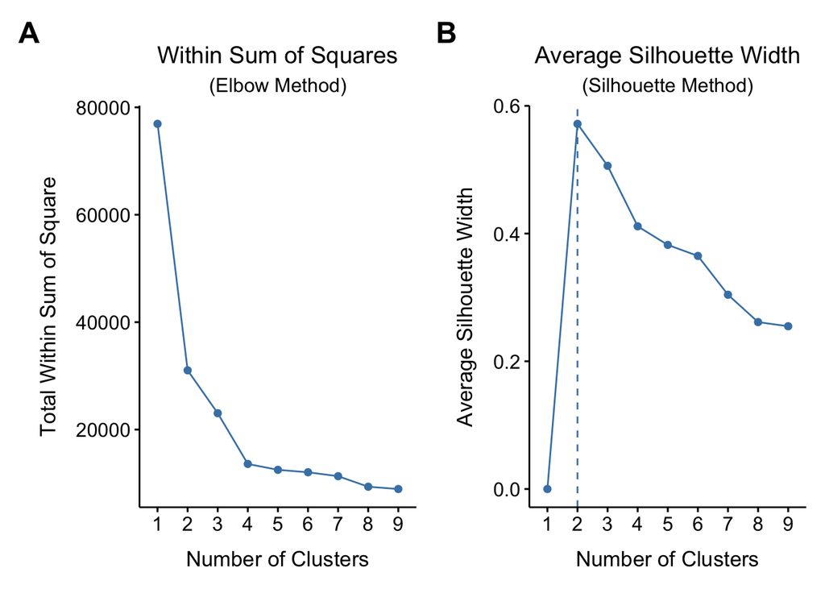

```r
# Calculate distance matrix
chem_dist <- vegdist(wb_log2_t, method = "euclidean")

# Visualizations for optimal number of clusters. k.max must be at most, one less than the smaller of the 2 dimensions of the data frame or it will bug.

# WSS
wss <- fviz_nbclust(wb_log2_t, method = "wss", diss = chem_dist, FUNcluster = hcut, hc_func="diana", k.max = 9) +
  ggtitle("Within Sum of Squares") +
  labs(subtitle = "(Elbow Method)",
       x = "Number of Clusters") +
  theme(plot.title = element_text(hjust = 0.5),
        plot.subtitle = element_text(hjust = 0.5),
        axis.title.x = element_text(margin = ggplot2::margin(t = 10), size = 13),
        axis.title.y = element_text(margin = ggplot2::margin(r = 10), size = 13))

# Silhouette
silhouette <- fviz_nbclust(wb_log2_t, method = "silhouette", diss = chem_dist, FUNcluster = hcut, hc_func="diana", k.max = 9) +
  ggtitle("Average Silhouette Width") +
  labs(subtitle = "(Silhouette Method)",
       x = "Number of Clusters",
       y = "Average Silhouette Width") +
  theme(plot.title = element_text(hjust = 0.5),
        plot.subtitle = element_text(hjust = 0.5),
        axis.title.x = element_text(margin = ggplot2::margin(t = 10), size = 13),
        axis.title.y = element_text(margin = ggplot2::margin(r = 10), size = 13))

# 2 or 4 clusters makes the most sense based on these graphs
log2data_clusterselect <- wss + silhouette +
  plot_annotation(tag_levels = 'A') &
  theme(plot.tag = element_text(face = "bold", size = 18))

pdf(file = "2_OutputFigs/Hclust_K_Select.pdf",
    width = 11,
    height = 5)

log2data_clusterselect

invisible(dev.off())

log2data_clusterselect
```

Plot heatmap of clusters:

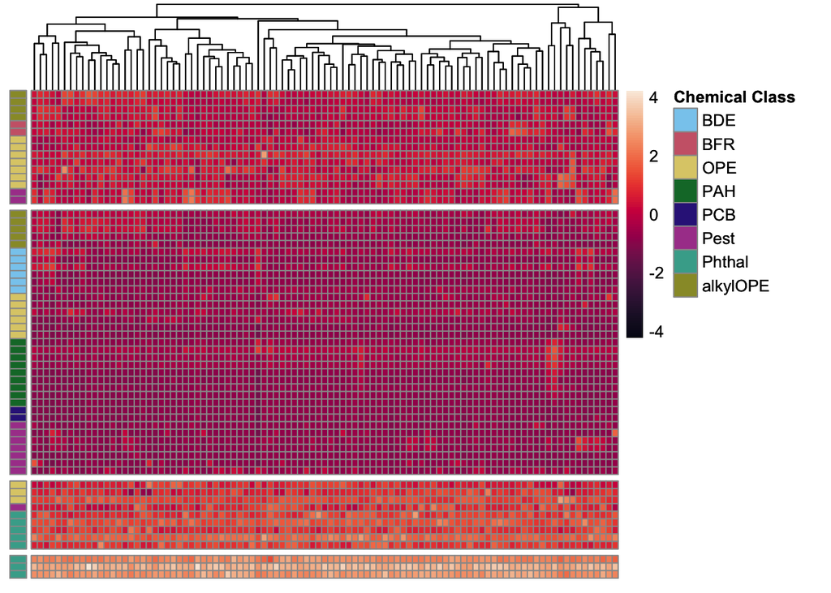

```r
# Run clustering algorithm
chem_clusters <- diana(chem_dist, diss=TRUE)

# Select 4 clusters of chemicals
ncut <- 4
cluster_assignments <- cutree(chem_clusters, k = ncut)

# Quantify number of chemicals in each cluster
k_chems <- table(cluster_assignments)

# Add in cluster assignment to data frame and arrange the data frame by cluster number
wb_log2_t$cluster <- cluster_assignments
wb_log2_t <- wb_log2_t %>% arrange(cluster)

# Add in index column and find where to add breaks in heat map to separate clusters
wb_log2_t$index <- 1:nrow(wb_log2_t)
hm_breaks <- wb_log2_t %>% group_by(cluster) %>% summarise(m=max(index))

# Data to plot in heat map
hm_data <- wb_log2_t %>% select(-c("cluster","index"))

# Make heat map
hclust_heatmap <- pheatmap(hm_data,
         annotation_row = hm_chemical_key,
         annotation_colors = heatmap_chemical_class_colors,
         annotation_names_row = FALSE,
         scale = 'column',
         cluster_rows = FALSE,
         cluster_cols = TRUE,
         show_rownames = FALSE,
         show_colnames = FALSE,
         gaps_row = hm_breaks$m,
         color = rocket(100))

pdf(file = "2_OutputFigs/Heatmap_Log2Data_ColScale_4Clust.pdf",
    width = 7,
    height = 5)
hclust_heatmap
invisible(dev.off())

hclust_heatmap
```

## 5.2 Standardized data (within-chemical scaled)

Prepare data. This code scales the data within each chemical, such that within each chemical, the participant with the highest exposure is assigned the highest number, and the participant with the lowest exposure is assigned the lowest number.

```r
wb_log2_sc_t <- wb %>%
  column_to_rownames("S_ID") %>% # Add subjects to row names to preserve IDs
  mutate(across(where(is.numeric), pseudolog)) %>%
  scale() %>% # Scale values
  t() %>% data.frame() %>%
  rename_with(~ str_replace(., "X", "S_"))
```

Select number of clusters:

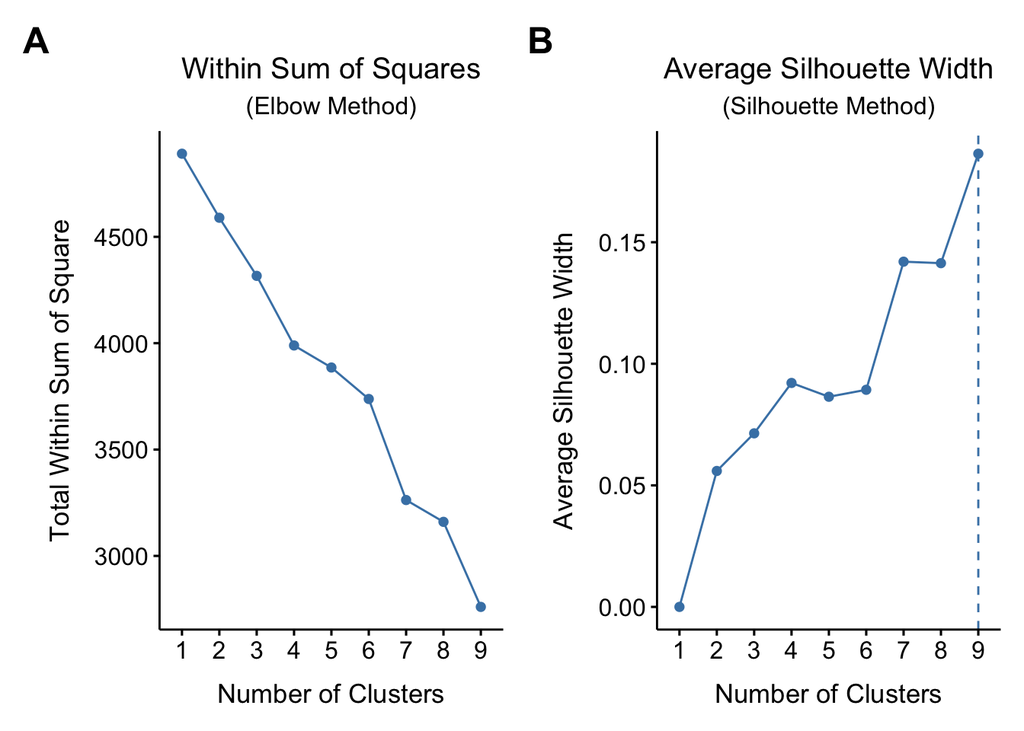

```r
# Calculate distance matrix
chem_dist <- vegdist(wb_log2_sc_t, method = "euclidean")

# Visualizations for optimal number of clusters. k.max must be at most, one less than the smaller of the 2 dimensions of the data frame or it will bug.

# WSS
wss <- fviz_nbclust(wb_log2_sc_t, method = "wss", diss = chem_dist, FUNcluster = hcut, hc_func="diana", k.max = 9) +
  ggtitle("Within Sum of Squares") +
  labs(subtitle = "(Elbow Method)",
       x = "Number of Clusters") +
  theme(plot.title = element_text(hjust = 0.5),
        plot.subtitle = element_text(hjust = 0.5),
        axis.title.x = element_text(margin = ggplot2::margin(t = 10), size = 13),
        axis.title.y = element_text(margin = ggplot2::margin(r = 10), size = 13))

# Silhouette
silhouette <- fviz_nbclust(wb_log2_sc_t, method = "silhouette", diss = chem_dist, FUNcluster = hcut, hc_func="diana", k.max = 9) +
  ggtitle("Average Silhouette Width") +
  labs(subtitle = "(Silhouette Method)",
       x = "Number of Clusters",
       y = "Average Silhouette Width") +
  theme(plot.title = element_text(hjust = 0.5),
        plot.subtitle = element_text(hjust = 0.5),
        axis.title.x = element_text(margin = ggplot2::margin(t = 10), size = 13),
        axis.title.y = element_text(margin = ggplot2::margin(r = 10), size = 13))

# 4 clusters makes the most sense based on these graphs
log2data_scaled_clusterselect <- wss + silhouette +
  plot_annotation(tag_levels = 'A') &
  theme(plot.tag = element_text(face = "bold", size = 18))

pdf(file = "2_OutputFigs/Hclust_K_Select_WithinChemScaled.pdf",
    width = 11,
    height = 5)

log2data_scaled_clusterselect

invisible(dev.off())

log2data_scaled_clusterselect
```

Run clustering:

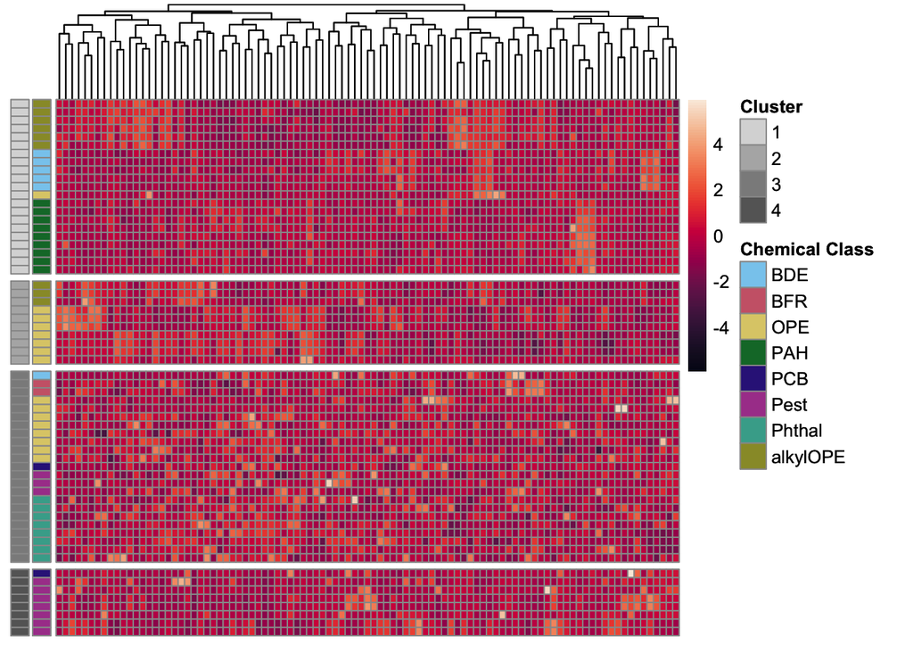

```r
# Run clustering algorithm
chem_clusters_sc <- diana(chem_dist, diss=TRUE)

# Select 4 clusters of chemicals
ncut <- 4
cluster_assignments_sc <- cutree(chem_clusters_sc, k = ncut)

# Quantify number of chemicals in each cluster
k_chems_sc <- table(cluster_assignments_sc)

# Add in cluster assignment to data frame and arrange the data frame by cluster number
wb_log2_sc_t$cluster <- cluster_assignments_sc
wb_log2_sc_t <- wb_log2_sc_t %>% arrange(cluster)

# Add in index column and find where to add breaks in heat map to separate clusters
wb_log2_sc_t$index <- 1:nrow(wb_log2_sc_t)
hm_breaks <- wb_log2_sc_t %>% group_by(cluster) %>% summarise(m=max(index))

# Data to plot in heat map
hm_data_sc_t <- wb_log2_sc_t %>% select(-c("cluster","index"))

# Extract cluster assignments
clust_assign_df <- wb_log2_sc_t %>%
  rownames_to_column("class_chemical") %>%
  select(c(class_chemical, cluster))

# Add cluster assignments to chemical key
hm_chemical_key <- hm_chemical_key %>%
  rownames_to_column("class_chemical") %>%
  left_join(clust_assign_df, by = "class_chemical") %>%
  column_to_rownames("class_chemical") %>%
  rename("Cluster" = "cluster") %>%
  mutate(Cluster = as.character(Cluster))

# Add group colors to chemical key
heatmap_chemical_class_colors = list("Chemical Class" = c(BDE = "#88CCEE",
                                               BFR = "#CC6677",
                                               OPE = "#DDCC77",
                                               PAH = "#117733",
                                               PCB = "#332288",
                                               Pest = "#AA4499",
                                               Phthal = "#44AA99",
                                               alkylOPE = "#999933"),
                                     "Cluster" = c(`1` = "gray85",
                                                   `2` = "gray70",
                                                   `3` = "gray55",
                                                   `4` = "gray40"))


# Make heat map
hclust_heatmap_inputscaled_chemical <- pheatmap(hm_data_sc_t,
         annotation_row = hm_chemical_key,
         annotation_colors = heatmap_chemical_class_colors,
         annotation_names_row = FALSE,
         scale = 'column',
         cluster_rows = FALSE,
         cluster_cols = TRUE,
         show_rownames = FALSE,
         show_colnames = FALSE,
         gaps_row = hm_breaks$m,
         color = rocket(100))

pdf(file = "2_OutputFigs/Heatmap_Log2DataWithinChemical_4Clust.pdf",
    width = 7,
    height = 5)
hclust_heatmap_inputscaled_chemical
invisible(dev.off())

hclust_heatmap_inputscaled_chemical
```

# 6 Correlation analysis

First, prepare scaled data frame that is not transposed:

```r
wb_log2_sc <- wb %>%
  column_to_rownames("S_ID") %>% # Add subjects to row names to preserve IDs
  mutate(across(where(is.numeric), pseudolog)) %>%
  scale() %>% # Scale values
  data.frame()
```

And modify the default cor.mtest function typically used in correlation analysis to use Spearman correlation (since our data are non-normally distributed):

```r
# To add significance to correlation analysis, run this function
cor.mtest.spearman <- function(mat, ...) {
  mat <- as.matrix(mat)
  n <- ncol(mat)
  p.mat<- matrix(NA, n, n)
  diag(p.mat) <- 0
  for (i in 1:(n - 1)) {
    for (j in (i + 1):n) {
      tmp <- cor.test(mat[, i], mat[, j], method = "spearman", exact = FALSE, ...)
      p.mat[i, j] <- p.mat[j, i] <- tmp$p.value
    }
  }
  colnames(p.mat) <- rownames(p.mat) <- colnames(mat)
  p.mat
}
```

## 6.1 All chemicals together

```r
# Calculate correlations and p-values
data_corr <- cor(as.matrix(wb_log2_sc), method = "spearman")
p.mat <- cor.mtest.spearman(as.matrix(wb_log2_sc))

# Extract upper triangle so that only unique pairs are included
corrsummary <- data.frame(var1 = rownames(data_corr)[row(data_corr)[upper.tri(data_corr)]],
           var2 = colnames(data_corr)[col(data_corr)[upper.tri(data_corr)]],
           corr = data_corr[upper.tri(data_corr)]) %>%
  unite(var1_var2, var1, var2, sep = "_", remove = FALSE)

psummary <- data.frame(var1 = rownames(p.mat)[row(p.mat)[upper.tri(p.mat)]],
           var2 = colnames(p.mat)[col(p.mat)[upper.tri(p.mat)]],
           pval = p.mat[upper.tri(p.mat)]) %>%
  unite(var1_var2, var1, var2, sep = "_", remove = TRUE)

# Merge data frames and calculate average R and p-value (to be used in graph below)
corrpval_all_spearman_sc <- right_join(corrsummary, psummary, by = "var1_var2") %>%
   mutate(corr_abs = abs(corr))

# Calculate average R, p-value, and percentage of correlations that are significant
correlation_summary_all <- data.frame(corr_avg = mean(corrpval_all_spearman_sc$corr_abs),
                                      p_avg = mean(corrpval_all_spearman_sc$pval),
                                      sig_count = nrow(corrpval_all_spearman_sc %>% filter(abs(corr) > 0.6 & pval < 0.05)))

correlation_summary_all <- correlation_summary_all %>%
      mutate(sig_perc = sig_count/nrow(corrpval_all_spearman_sc)*100)

correlation_summary_all
```

```
##    corr_avg     p_avg sig_count sig_perc
## 1 0.2183671 0.2030666        57 3.014278
```

## 6.2 By hierarchical cluster

First, split the data frame into a list by cluster:

```r
# Extract cluster assignments
clust_assign_df <- wb_log2_sc_t %>%
  rownames_to_column("class_chemical") %>%
  select(c(class_chemical, cluster))

# Add cluster assignments to data frame and make data frame into a list
hclust_df_list <- wb_log2_sc %>%
  t() %>% as.data.frame() %>%
  rownames_to_column("class_chemical") %>%
  left_join(clust_assign_df, by = "class_chemical") %>%
  split(f = as.factor(.$cluster))
```

Then, clean each of the data frames:

```r
# Function for cleaning data frame to prepare for correlation calculation
df_list_cleaning <- function(listed_df) {
    listed_df %>%
    remove_rownames() %>%
      column_to_rownames("class_chemical") %>%
      t()
}

# Clean each data frame to prepare for correlation calculations
hclust_df_list <- lapply(hclust_df_list, df_list_cleaning)
```

And compute correlations from each data frame:

```r
# Compute correlations from each data frame
hclust_correlations <- lapply(hclust_df_list, function(x) {

    # Compute correlations
    data_corr <- cor(x, method = "spearman")

    # Compute p-values
    p.mat <- cor.mtest.spearman(x)

    # Summarize R values
    corrsummary <- data.frame(var1 = rownames(data_corr)[row(data_corr)[upper.tri(data_corr)]],
           var2 = colnames(data_corr)[col(data_corr)[upper.tri(data_corr)]],
           corr = data_corr[upper.tri(data_corr)]) %>%
      unite(var1_var2, var1, var2, sep = "_", remove = FALSE)

    # Summarize p values
    psummary <- data.frame(var1 = rownames(p.mat)[row(p.mat)[upper.tri(p.mat)]],
           var2 = colnames(p.mat)[col(p.mat)[upper.tri(p.mat)]],
           pval = p.mat[upper.tri(p.mat)]) %>%
      unite(var1_var2, var1, var2, sep = "_", remove = TRUE)

    # Merge data frames
    all_correlations <- right_join(corrsummary, psummary, by = "var1_var2") %>%
      mutate(corr_abs = abs(corr))

    # Calculate average correlation and p-value per group, summarize in data table
    correlation_summary <- data.frame(corr_avg = mean(all_correlations$corr_abs),
                                      p_avg = mean(all_correlations$pval),
                                      sig_count = nrow(all_correlations %>% filter(abs(corr) > 0.6 & pval < 0.05)))

    correlation_summary <- correlation_summary %>%
      mutate(sig_perc = sig_count/nrow(all_correlations)*100)

    # Make a list for output
    # list(all_correlations, correlation_summary)

    return(correlation_summary)
  })

# Unlist data frame for final summary data frame
hclust_correlations <- Map(cbind, hclust_correlations, cluster = names(hclust_correlations))
hclust_correlations <- do.call(rbind, hclust_correlations)
```

## 6.3 Visualizing results

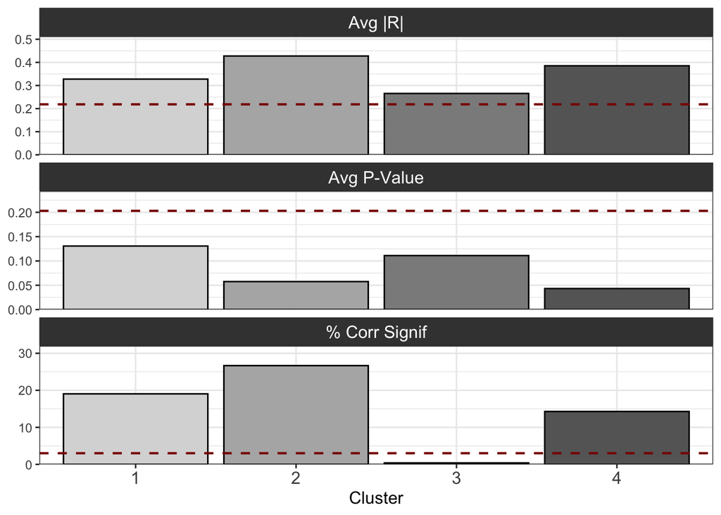

```r
# Make data frame with lines to plot from correlation between all chemicals analysis
correlations_ref_spearman <- correlation_summary_all %>%
  select(-sig_count) %>%
  pivot_longer(corr_avg:sig_perc, values_to = "value_ref", names_to = "variable")

# Prepare by cluster data for graphing
hclust_correlations_forgraphing <- hclust_correlations %>%
  select(-sig_count) %>%
  pivot_longer(corr_avg:sig_perc, values_to = "value", names_to = "variable")

# Combine data frames
corr_performance_forgraphing <- hclust_correlations_forgraphing %>%
  left_join(correlations_ref_spearman, by = "variable") %>%
  mutate(value_ref = as.numeric(value_ref)) %>%
  mutate(value = as.numeric(value))

# Create labels
corr_performance_forgraphing$variable <- factor(corr_performance_forgraphing$variable, levels = c("corr_avg", "p_avg", "sig_perc"),
                                   labels = c("Avg |R|", "Avg P-Value", "% Corr Signif"))

# Make graph
hclust_spearman_corr_performance <- ggplot() +
  geom_col(corr_performance_forgraphing, mapping = aes(x = cluster, y = value, fill = cluster), color = "black") +
  scale_fill_manual(values = c("gray85","gray70", "gray55","gray40")) +
  geom_hline(corr_performance_forgraphing, mapping = aes(yintercept = value_ref), color = "red4", linetype = "dashed", linewidth = 0.75) +
  facet_wrap(~variable, scales = "free_y", nrow = 3) +
  labs(x = "Cluster") +
  scale_y_continuous(expand = expansion(mult = c(0, 0.2))) +
  theme(axis.title.y = element_blank(),
        axis.title.x = element_text(size = 12),
        axis.text.x = element_text(size = 12),
        legend.position = "none",
        strip.background = element_rect(fill ="gray25"),
        strip.text = element_text(color = "white", size = 12))

pdf(hclust_spearman_corr_performance, file = "2_OutputFigs/Hclust_Corr_Performance.pdf",
    height = 6,
    width = 3)
hclust_spearman_corr_performance
invisible(dev.off())

hclust_spearman_corr_performance
```